# 07 - Performance and Discussion

Hannah Harrison

2022-11-17

# Performance testing

## The test data

```r
if (!require("fs")) install.packages("fs")
library("fs")
```

Load the data:

```r
kdd_10_test =read.table(path_wd("..","data","kdd_10_test.tab"),header=TRUE)
labeled_test =read.table(path_wd("..","data","labeled_test.tab"),header=TRUE)
```

One of the reasons that we chose to look at the labeled test data is the aggravating factor that the distribution of attack classes is very different to the kdd_10 data. This difference between the two test sets can be seen in the tables and charts below.

```r
table(kdd_10_test$class)
```

```
##
##   DDoS normal  Probe    R2L    UR2
##  39147   9744    395    112      4
```

```r
prop.table(table(kdd_10_test$class))
```

```
##
##         DDoS       normal        Probe          R2L          UR2
## 7.924173e-01 1.972390e-01 7.995628e-03 2.267115e-03 8.096838e-05
```

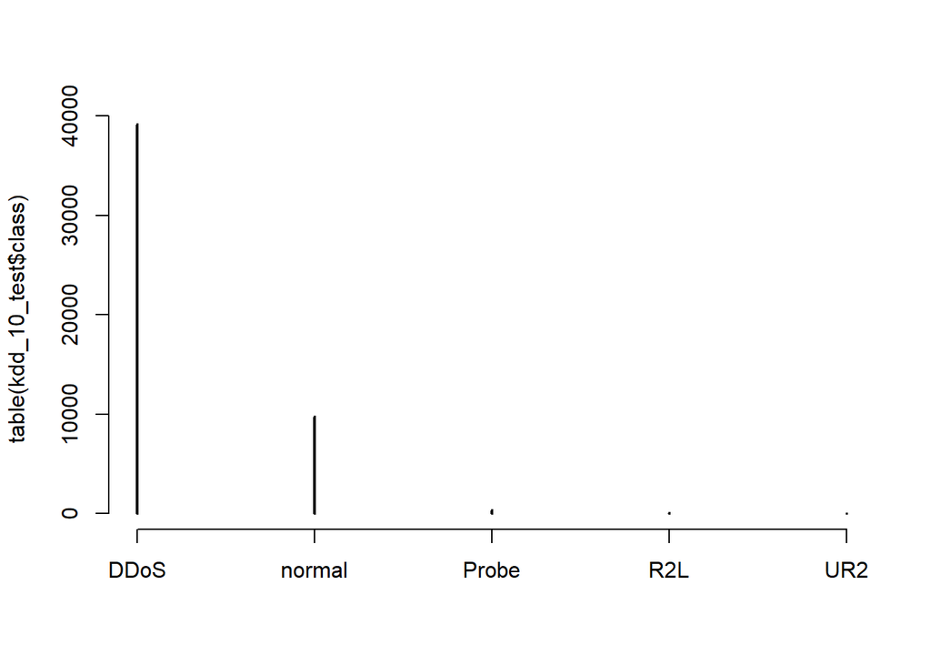

```r
plot(table(kdd_10_test$class))
```

```r
table(labeled_test$class)
```

```
##
##   DDoS normal  Probe    R2L    UR2
## 229853  60592   4166  13781   2636
```

```r
prop.table(table(labeled_test$class))
```

```
##
##        DDoS      normal       Probe         R2L         UR2
## 0.739010636 0.194812043 0.013394292 0.044307908 0.008475121
```

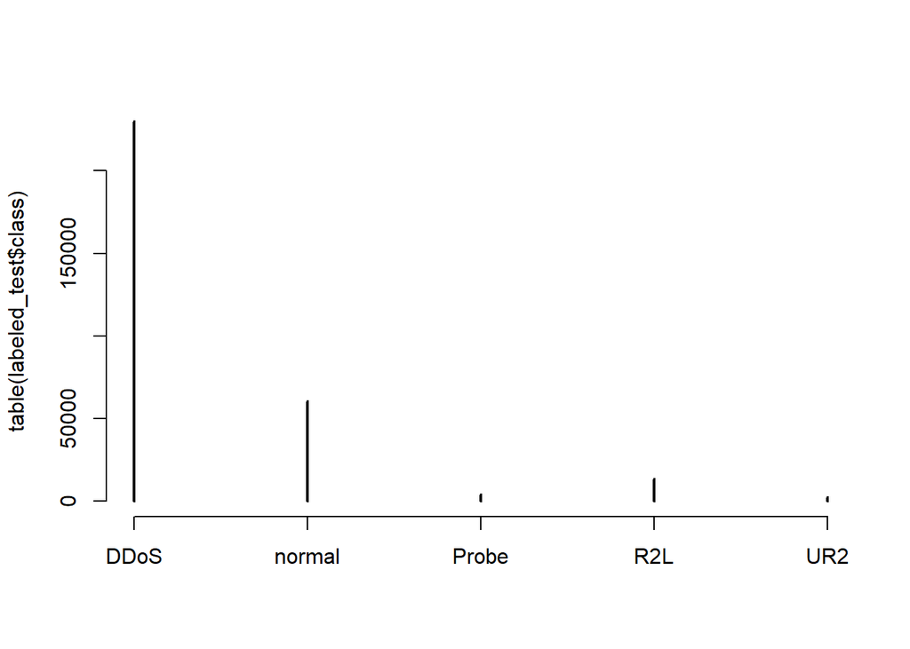

```r
plot(table(labeled_test$class))
```

In particular, the kdd_10 data contains very few instances of Probe, R2L and UR2 at all, whereas the labeled test set contains larger proportions of each. It will be interesting to see what difference this makes to the models’ performance.

As set out in the introduction, the modes will be compared based on the following three performance metrics: 1. Accuracy 2. Precision for each attack type, as we want to consider the proportion of positive identifications that are actually correct 3. The recall (i.e. sensitivity) of less common attack classes in the test data (R2L, Probe and UR2)

## KDD_10

We first evaluate the models’ performance on the left out data from the 10 percent dataset, i.e. the test data with the same distribution as the training data.

### Model 1: Xgboost

Confusion Matrix and Statistics

```
      Reference
Prediction  DDoS  Normal  Probe R2L   UR2
      DDos 39205     0     0     0     0
    Normal     0  9703     0     0     0
     Probe     0     0   390     0     0
       R2L     0     0     0   102     0
       UR2     0     0     0     0     2

Statistics by Class:
                   DDoS    Normal Probe    R2L      UR2
Sensitivity            1.0000   1.0000 1.000000 1.000000 1.000e+00
Specificity            1.0000   1.0000 1.000000 1.000000 1.000e+00
Pos Pred Value         1.0000   1.0000 1.000000 1.000000 1.000e+00
Neg Pred Value         1.0000   1.0000 1.000000 1.000000 1.000e+00
Precision              1.0000   1.0000 1.000000 1.000000 1.000e+00
Recall                 1.0000   1.0000 1.000000 1.000000 1.000e+00
F1                     1.0000   1.0000 1.000000 1.000000 1.000e+00
```

### Model 2: Multi-logistic Regression

```
Confusion matrix:

        normal  probe  ur2   ddos  r2l
normal    9341     60   21      0  397
probe       19    383    1      0    0
ur2          2      0    2      0    2
ddos       333     67    0  38660    3
r2l          2      0    2      0

 index:    precision    recall  f1-score   support

    normal     0.9633    0.9513    0.9573      9819
     probe     0.7510    0.9504    0.8390       403
       ur2     0.0769    0.3333    0.1250         6
       ddos    1.0000    0.9897    0.9948     39063
       r2l     0.2102    0.9640    0.3452       111

accuracy                         0.9816     49402
```

### Model 3: KNN

```
        normal  probe   ur2 ddos    r2l
normal  3580       75     281    0   156
probe     598       240    1     4    10
ur2     356      1     0   0       3
ddos      1246    157      6    38101    3
r2l     2015       0      16     1    15

         precision    recall  f1-score   support

     Normal   0.36      0.99      0.53      3611
     DDoS     0.97      0.98      0.97     38871
     UR2      0.00      0.00      0.00         0
     R2L      0.43      0.01      0.02      5291
     Probe    0.66      0.16      0.26      1629

accuracy                           0.85     49402
```

### Comparison

Here we can see that, as it achieves 100% accuracy, the xgboost model clearly has the best performance on this dataset, which isn’t too surprising as this test data comes from the same distribution as the training. The more interesting comparison comes between the other two models.

In terms of recall, model 3 has extremely high scores for normal and DDoS attacks, and very low scores for the other three classes, whereas (apart from UR2), the scores for model 2 are more balanced. This ephasises the problem that model 3 is predicting normal too often, and shows that model 2 is better at distributing predictions between classes, although we can see from the confusion matrix that it does still suffer from the over-prediction of normal.

We can see by the low precision scores for R2L, and low precision and recall scores in both models 2 and 3 for UR2, that the models are already struggling with the smaller classes. In fact, model 3 doesn’t predict UR2 at all! This may be exacerbated in the labeled test data predictions.

## Labeled_test

We now evaluate the models’ performance on the labeled test dataset, i.e. the test data with a different distribution of attacks to the training data.

### Model 1: Xgboost

```
Confusion Matrix and Statistics

          Reference
Prediction  DDoS  Normal  Probe R2L   UR2
      DDos 229853      0      0      0      0
    Normal      0  60592      0      0      0
     Probe      0      0   4166      0      0
       R2L      0      0      0  13781      0
       UR2      0      0      0      0   2636
```

Statistics by Class

```
                       DDoS    Normal Probe    R2L      UR2
Sensitivity             1.000   1.0000  1.00000  1.00000 1.000000
Specificity             1.000   1.0000  1.00000  1.00000 1.000000
Pos Pred Value          1.000   1.0000  1.00000  1.00000 1.000000
Neg Pred Value          1.000   1.0000  1.00000  1.00000 1.000000
Precision               1.000   1.0000  1.00000  1.00000 1.000000
Recall                  1.000   1.0000  1.00000  1.00000 1.000000
F1                      1.000   1.0000  1.00000  1.00000 1.000000
```

### Model 2: Multi-logistic Regression

Confusion matrix:

```
            normal  probe  ur2    ddos   r2l
    normal   58615    475   92     598   811
    probe      592   3473    8      23    70
    ur2       2564      5   49       0    18
    ddos     40121    510    5  189202    15
    r2l      12080      1   22       1  1677

 index:    precision    recall  f1-score   support
  normal     0.5143    0.9674    0.6716     60591
   probe     0.7780    0.8337    0.8049      4166
     ur2     0.2784    0.0186    0.0349      2636
    ddos     0.9967    0.8231    0.9017    229853
     r2l     0.6472    0.1217    0.2049     13781

accuracy                         0.8135    311027
```

### Model 3: KNN

```
          normal    probe   ur2 ddos    r2l
normal  83286     104     91    210   624
probe     3012    270     5   21      50
ur2     2453       3      0    0      15
ddos      7396    502     6 221933  16
r2l     10045      0     52    5      52

         precision    recall  f1-score   support

Normal       1.00      0.72      0.84     83286
  DDoS       0.96      1.00      0.98    221933
   UR2       0.00      0.60      0.00        10
   R2L       0.07      0.91      0.12      1006
 Probe       0.75      0.65      0.70      4793

Accuracy                           0.92    311028
```

### Comparison

The first immediate observation is that the xgboost model again achieves 100% accuracy, which is more surprising this time, as the test data contains attack types which weren’t present in the training data. This indicates that such decision tree models may be the superior choice for this type of problem.

Interestingly, on this dataset, we see a switch in the order of the performance of models 2 and 3 in terms of accuracy. Indeed, the accuracy for the KNN model on this test set is surprisingly much higher than on the previous test set. Without further investigation, this could lead to the conclusion that model 3 is automatically a good choice for data from a different distribution to the training. However, looking at the other metrics, we can see that again UR2 is never correctly predicted, and this higher accuracy comes from the model being very good at predicting the two classes dominating the data (normal and DDoS). Hence this model would be a poor choice if we care about the smaller classes, as we can see from the confusion matrix that the model predicts these classes far too often and rarely gets it right.

To conclude, on this set, the xgboost model is the superior choice, and both models 2 and 3 suffer from over-predicting normal in attack instances.

Overall, with 100% accuracy on both sets, the xgboost model is hard to beat. The multi logistic regression model performs well on the kdd_10 test data but performance falls significantly when the test data comes from a different distribution. The KNN model is very good at predicting DDoS attacks on both datasets, but struggles to distinguish the other classes.